# Calculating Walking and cycling trips impedance function- 2005

# Active-transport walking and cycling behaviour in Canada

## Data and Method

Data on walking and cycling trips to different destinations was derived from Canada’s General Social Survey (GSS) from 1986 to 2015. GSS is a social trends survey in order to monitor changes in the living conditions and well-being of Canadians and to provide information on specific social policy issues. one of the important information of GSS is about Time-use surveys. This survey collects information on all human activities and can therefore inform a broad range of policies. Statistics Canada has been conducting time-use surveys since 1986 at approximately five- to seven- year intervals, most recently in 2015.The GSS on time use employs a retrospective 24-hour time diary to collect information on respondents’ participation in, and time spent on, a wide variety of day-to-day activities. In addition, information is collected on the location where these activities occurred (e.g., at home, at work, etc.).in addition, This dataset contains travel time data of Many of the Census Metropolitan Areas (CMAs) and non-CMA areas all over Canada. CMAs are including St. John’s, Halifax, Saint John, Montreal, Quebec City, Toronto, Ottawa, Hamilton, Winnipeg, Regina, Saskatoon, Calgary, Edmonton, and Vancouver. and the non-CMA areas of each of the ten provinces were also grouped to form ten more strata.

# Result

First load all of the libraries

Here, we are loading all the primary files of the GSS dataset to create our database for analysis.

### Calculating impedance function for walking in 2005

```r
count <- sum(walking_2005$DURATION > 100)
print (count)
```

```
[1] 15
```

```r
walking_2005 <- walking_2005 %>% filter(DURATION < 100)
summary(walking_2005$DURATION)
```

```
   Min. 1st Qu.  Median    Mean 3rd Qu.    Max.
   0.00    5.00   10.00   11.51   15.00   90.00
```

using a skew vs. kurtois graph to descriptive statistics of data:

```
summary statistics
------
min:  0   max:  90
median:  10
mean:  11.50843
estimated sd:  11.31705
estimated skewness:  2.506023
estimated kurtosis:  12.1267
```

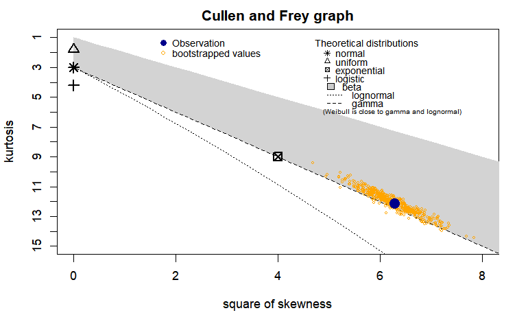

```r
# creating a skew vs. kurtois graph for walking 2005

descdist(walking_2005$DURATION %>% unlist() %>% as.numeric(), discrete=FALSE, boot=500)
```

As shown in the Cullen and Frey graph, we see that Weibull, gamma,and exponential will likely be the best fit according to the graph above. Then we compare these models to find the best model.

```r
# The Duration column contains four zero values. Before proceeding to calculate the gamma, weibull and lognormal distribution, a preprocessing step was undertaken, converting these zero values to the value of five.

# Calculating zero values
zero_count <- sum(walking_2005$DURATION == 0)
cat("Number of 0 values in DURATION column:", zero_count)
```

```
Number of 0 values in DURATION column: 4
```

```r
# change 0 value to 5
walking_2005$DURATION[walking_2005$DURATION == 0] <- 5

# Based on the skew vs. kurtois graph the best distribution

#Calculating gamma distribution

gamma_w_2005_ <- fitdistrplus::fitdist(data=walking_2005$DURATION%>% unlist() %>% as.numeric(), "gamma", method="mle", optim.method="Nelder-Mead", weights = round(walking_2005$WGHT_EPI))
fit_dgamma <- data.frame(f = dgamma(walking_2005$DURATION, shape = gamma_w_2005_$estimate[1], rate = gamma_w_2005_$estimate[2]), x = walking_2005$DURATION, type = "Gamma")

summary(gamma_w_2005_)
```

```
Fitting of the distribution ' gamma ' by maximum likelihood
Parameters :
```

|  | estimate | Std. Error |
| --- | --- | --- |
| shape | 1.3873033 | 6.698465e-04 |
| rate | 0.1192402 | 6.908658e-05 |

```
Loglikelihood:  -24049571   AIC:  48099147   BIC:  48099160
Correlation matrix:
          shape      rate
shape 1.0000000 0.8332624
rate  0.8332624 1.0000000
```

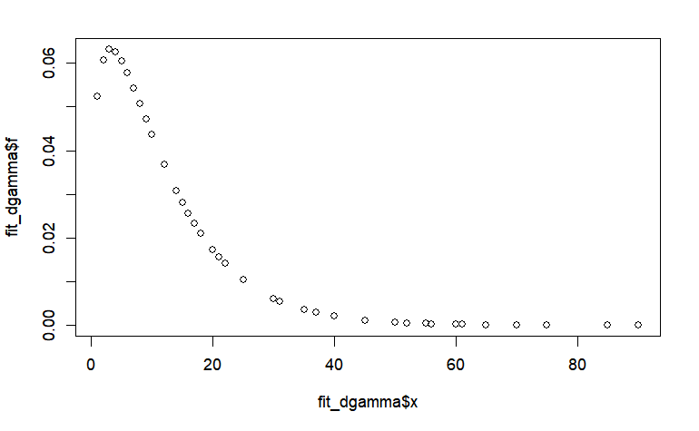

```r
plot(x= fit_dgamma$x, y=fit_dgamma$f)
```

```r
#Calculating weibull distribution
weibull_w_2005_ <- fitdistrplus::fitdist(data=walking_2005$DURATION%>% unlist() %>% as.numeric(), "weibull", method="mle", optim.method="Nelder-Mead", weights = round(walking_2005$WGHT_EPI))
summary(weibull_w_2005_)
```

```
Fitting of the distribution ' weibull ' by maximum likelihood
Parameters :
```

|  | estimate | Std. Error |
| --- | --- | --- |
| shape | 1.153635 | 0.0003207193 |
| scale | 12.296491 | 0.0042586816 |

```
Loglikelihood:  -24138578   AIC:  48277159   BIC:  48277172
Correlation matrix:
          shape     scale
shape 1.0000000 0.3290607
scale 0.3290607 1.0000000
```

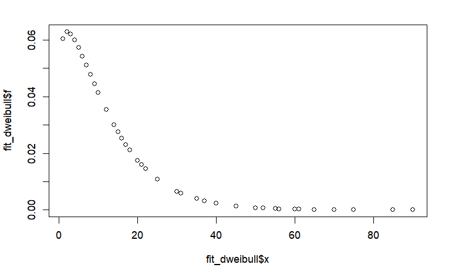

```r
fit_dweibull <- data.frame(f = dweibull(walking_2005$DURATION, shape = weibull_w_2005_$estimate[1], scale = weibull_w_2005_$estimate[2]), x = walking_2005$DURATION, type = "weibull")

plot(x= fit_dweibull$x, y=fit_dweibull$f)
```

```r
#Calculating exponential distribution
exp_w_2005_ <- fitdistrplus::fitdist(data=walking_2005$DURATION%>% unlist() %>% as.numeric(), "exp", method="mle", optim.method="Nelder-Mead", weights = round(walking_2005$WGHT_EPI))
summary(exp_w_2005_)
```

```
Fitting of the distribution ' exp ' by maximum likelihood
Parameters :
```

|  | estimate | Std. Error |
| --- | --- | --- |
| rate | 0.08591538 | 3.241369e-05 |

```
Loglikelihood:  -24260083   AIC:  48520169   BIC:  48520175
```

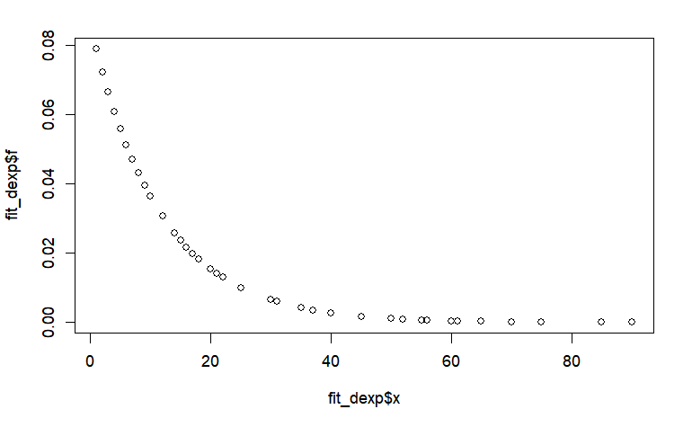

```r
# Get the estimated rate parameter from the fitted distribution
rate_estimate <- exp_w_2005_$estimate[1]

# Create a data frame for the fitted exponential distribution
fit_dexp <- data.frame(f = dexp(walking_2005$DURATION, rate = rate_estimate),
                       x = walking_2005$DURATION, type = "exp")

# Plot the fitted exponential distribution
plot(x = fit_dexp$x, y = fit_dexp$f)
```

Now let’s compare these models based on AIC and BIC to see which fits the walk data best:

```r
#comparing these models AIC and BIC to see which fits the walk data best:
broom::glance(MASS::fitdistr(walking_2005$DURATION%>% unlist() %>% as.numeric(),"gamma"))
```

| logLik | AIC | BIC | nobs |
| --- | --- | --- | --- |
| -18852.28 | 37708.56 | 37721.79 | 5517 |

```r
broom::glance(MASS::fitdistr(walking_2005$DURATION%>% unlist() %>% as.numeric(),"weibull"))
```

| logLik | AIC | BIC | nobs |
| --- | --- | --- | --- |
| -18916.2 | 37836.4 | 37849.63 | 5517 |

```r
broom::glance(MASS::fitdistr(walking_2005$DURATION%>% unlist() %>% as.numeric(),"exponential"))
```

| logLik | AIC | BIC | nobs |
| --- | --- | --- | --- |
| -18997.21 | 37996.42 | 38003.03 | 5517 |

```r
walking_2005_gamma <- gamma_w_2005_
walking_2005 <- walking_2005 %>%
 mutate(f = dgamma(DURATION, walking_2005_gamma$estimate["shape"], walking_2005_gamma$estimate["rate"]))
summary(walking_2005$f)
```

```
     Min.   1st Qu.    Median      Mean   3rd Qu.      Max.
7.350e-06 2.812e-02 4.363e-02 4.275e-02 6.054e-02 6.306e-02
```

##Calculating Impedance function based on different purposes

###Destination :Home (1)

using a skew vs. kurtois graph to descriptive statistics of data

```
summary statistics
------
min:  1   max:  90
median:  10
mean:  12.50655
estimated sd:  12.21711
estimated skewness:  2.386176
estimated kurtosis:  10.97568
```

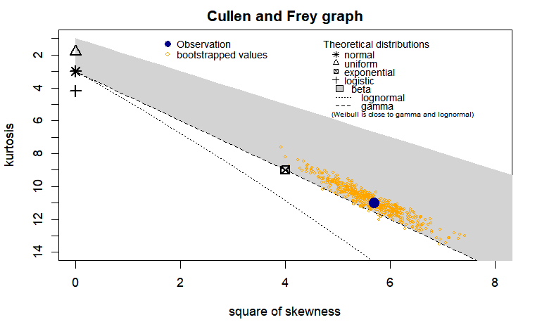

```r
# creating a skew vs. kurtois graph for walking 2005

# Filter the data based on the "destination" column
 w_1_2005 <- walking_2005 %>%
  filter(destination == "1")
descdist(w_1_2005$DURATION %>% unlist() %>% as.numeric(), discrete=FALSE, boot=500)
```

As shown in the Cullen and Frey graph, we see that gamma,weibull, and exponential will likely be the best fit according to the graph above. Then we compare these models to find the best model.

```r
# Based on the skew vs. kurtois graph the best distribution

#Calculating gamma distribution
gamma_w1_2005_ <- fitdistrplus::fitdist(data=w_1_2005$DURATION%>% unlist() %>% as.numeric(), "gamma", method="mle", optim.method="Nelder-Mead", weights = round(w_1_2005$WGHT_EPI))
fit_dgamma_w105 <- data.frame(f = dgamma(w_1_2005$DURATION, shape = gamma_w1_2005_$estimate[1], rate = gamma_w1_2005_$estimate[2]), x = w_1_2005$DURATION, type = "Gamma")

summary(gamma_w1_2005_)
```

```
Fitting of the distribution ' gamma ' by maximum likelihood
Parameters :
```

|  | estimate | Std. Error |
| --- | --- | --- |
| shape | 1.3693088 | 1.008362e-03 |
| rate | 0.1056473 | 9.357067e-05 |

```
Loglikelihood:  -10648925   AIC:  21297855   BIC:  21297866
Correlation matrix:
          shape      rate
shape 1.0000000 0.8313212
rate  0.8313212 1.0000000
```

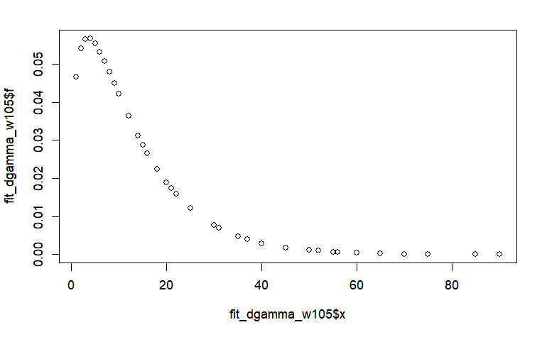

```r
plot(x= fit_dgamma_w105$x, y=fit_dgamma_w105$f)
```

```r
#Calculating weibull distribution
weibull_w1_2005_ <- fitdistrplus::fitdist(data=w_1_2005$DURATION%>% unlist() %>% as.numeric(), "weibull", method="mle", optim.method="Nelder-Mead", weights = round(w_1_2005$WGHT_EPI))
summary(weibull_w1_2005_)
```

```
Fitting of the distribution ' weibull ' by maximum likelihood
Parameters :
```

|  | estimate | Std. Error |
| --- | --- | --- |
| shape | 1.153906 | 0.0004935677 |
| scale | 13.689877 | 0.0072325935 |

```
Loglikelihood:  -10681023   AIC:  21362051   BIC:  21362062
Correlation matrix:
          shape     scale
shape 1.0000000 0.3272553
scale 0.3272553 1.0000000
```

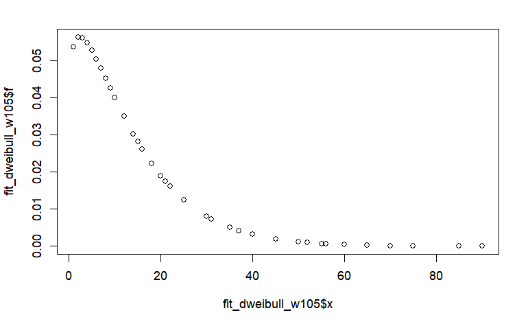

```r
fit_dweibull_w105 <- data.frame(f = dweibull(w_1_2005$DURATION, shape = weibull_w1_2005_$estimate[1], scale = weibull_w1_2005_$estimate[2]), x = w_1_2005$DURATION, type = "weibull")

plot(x= fit_dweibull_w105$x, y=fit_dweibull_w105$f)
```

```r
#Calculating exponential distribution
exp_w1_2005_ <- fitdistrplus::fitdist(data=w_1_2005$DURATION%>% unlist() %>% as.numeric(), "exp", method="mle", optim.method="Nelder-Mead", weights = round(w_1_2005$WGHT_EPI))
summary(exp_w1_2005_)
```

```
Fitting of the distribution ' exp ' by maximum likelihood
Parameters :
```

|  | estimate | Std. Error |
| --- | --- | --- |
| rate | 0.0771471 | 4.44355e-05 |

```
Loglikelihood:  -10732697   AIC:  21465395   BIC:  21465401
```

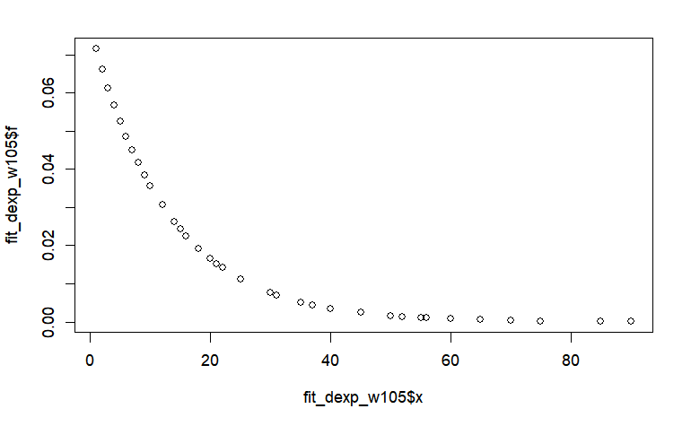

```r
fit_dexp_w105 <- data.frame(f = dexp(w_1_2005$DURATION, rate = exp_w1_2005_$estimate[1]),
                       x = w_1_2005$DURATION, type = "exp")

plot(x = fit_dexp_w105$x, y = fit_dexp_w105$f)
```

Now let’s compare these models AIC and BIC to see which fits the walk data best:

```r
#comparing these models AIC and BIC to see which fits the walk data best:
broom::glance(MASS::fitdistr(w_1_2005$DURATION%>% unlist() %>% as.numeric(),"gamma"))
```

| logLik | AIC | BIC | nobs |
| --- | --- | --- | --- |
| -8561.053 | 17126.11 | 17137.71 | 2444 |

```r
broom::glance(MASS::fitdistr(w_1_2005$DURATION%>% unlist() %>% as.numeric(),"weibull"))
```

| logLik | AIC | BIC | nobs |
| --- | --- | --- | --- |
| -8585.213 | 17174.43 | 17186.03 | 2444 |

```r
broom::glance(MASS::fitdistr(w_1_2005$DURATION%>% unlist() %>% as.numeric(),"exponential"))
```

| logLik | AIC | BIC | nobs |
| --- | --- | --- | --- |
| -8618.16 | 17238.32 | 17244.12 | 2444 |

```r
walking_105_gamma <- gamma_w1_2005_
w_1_2005 <- w_1_2005 %>%
 mutate(f_1 = dgamma(DURATION, walking_105_gamma$estimate["shape"], walking_105_gamma$estimate["rate"]))
summary(w_1_2005$f_1)
```

```
     Min.   1st Qu.    Median      Mean   3rd Qu.      Max.
2.026e-05 2.887e-02 4.215e-02 3.861e-02 5.534e-02 5.664e-02
```

###Destination : Work or school (2 and 8)

using a skew vs. kurtois graph to descriptive statistics of data

```
summary statistics
------
min:  1   max:  70
median:  10
mean:  11.8929
estimated sd:  11.0915
estimated skewness:  2.149835
estimated kurtosis:  8.798583
```

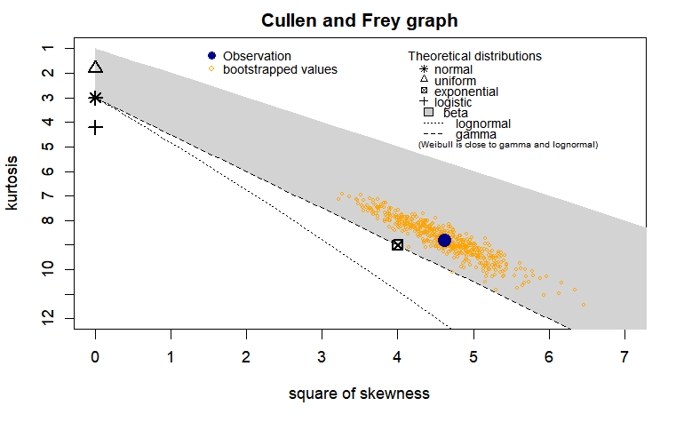

```r
# creating a skew vs. kurtois graph for walking 2005

# Filter the data based on the "destination" column
 w_2_2005 <- walking_2005 %>%
  filter(destination %in% c("2", "8"))
descdist(w_2_2005$DURATION %>% unlist() %>% as.numeric(), discrete=FALSE, boot=500)
```

As shown in the Cullen and Frey graph, we see that gamma,weibull, and exponential will likely be the best fit according to the graph above. Then we compare these models to find the best model.

```r
# Based on the skew vs. kurtois graph the best distribution

#Calculating gamma distribution
gamma_w2_2005_ <- fitdistrplus::fitdist(data=w_2_2005$DURATION%>% unlist() %>% as.numeric(), "gamma", method="mle", optim.method="Nelder-Mead", weights = round(w_2_2005$WGHT_EPI))
fit_dgamma_w205 <- data.frame(f = dgamma(w_2_2005$DURATION, shape = gamma_w2_2005_$estimate[1], rate = gamma_w2_2005_$estimate[2]), x = w_2_2005$DURATION, type = "Gamma")

summary(gamma_w2_2005_)
```

```
Fitting of the distribution ' gamma ' by maximum likelihood
Parameters :
```

|  | estimate | Std. Error |
| --- | --- | --- |
| shape | 1.4389768 | 0.001531768 |
| rate | 0.1265437 | 0.000160616 |

```
Loglikelihood:  -4933926   AIC:  9867855   BIC:  9867865
Correlation matrix:
          shape      rate
shape 1.0000000 0.8385823
rate  0.8385823 1.0000000
```

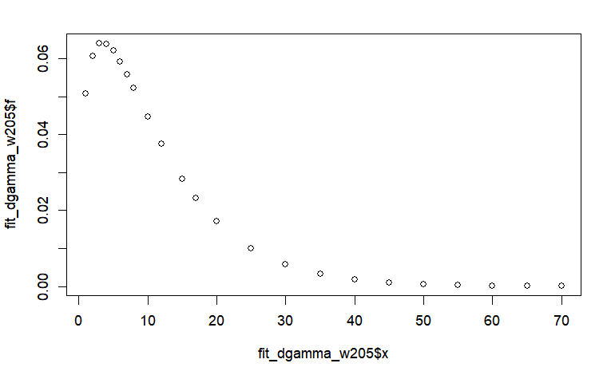

```r
plot(x= fit_dgamma_w205$x, y=fit_dgamma_w205$f)
```

```r
#Calculating weibull distribution
weibull_w2_2005_ <- fitdistrplus::fitdist(data=w_2_2005$DURATION%>% unlist() %>% as.numeric(), "weibull", method="mle", optim.method="Nelder-Mead", weights = round(w_2_2005$WGHT_EPI))
summary(weibull_w2_2005_)
```

```
Fitting of the distribution ' weibull ' by maximum likelihood
Parameters :
```

|  | estimate | Std. Error |
| --- | --- | --- |
| shape | 1.175634 | 0.000718006 |
| scale | 12.094921 | 0.009040045 |

```
Loglikelihood:  -4955062   AIC:  9910127   BIC:  9910137
Correlation matrix:
          shape     scale
shape 1.0000000 0.3297288
scale 0.3297288 1.0000000
```

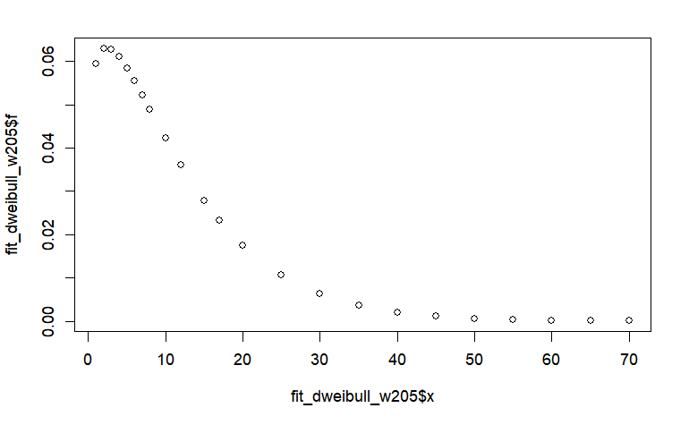

```r
fit_dweibull_w205 <- data.frame(f = dweibull(w_2_2005$DURATION, shape = weibull_w2_2005_$estimate[1], scale = weibull_w2_2005_$estimate[2]), x = w_2_2005$DURATION, type = "weibull")

plot(x= fit_dweibull_w205$x, y=fit_dweibull_w205$f)
```

```r
#Calculating exponential distribution
exp_w2_2005_ <- fitdistrplus::fitdist(data=w_2_2005$DURATION%>% unlist() %>% as.numeric(), "exp", method="mle", optim.method="Nelder-Mead", weights = round(w_2_2005$WGHT_EPI))
summary(exp_w2_2005_)
```

```
Fitting of the distribution ' exp ' by maximum likelihood
Parameters :
```

|  | estimate | Std. Error |
| --- | --- | --- |
| rate | 0.08789386 | 7.289902e-05 |

```
Loglikelihood:  -4986984   AIC:  9973970   BIC:  9973975
```

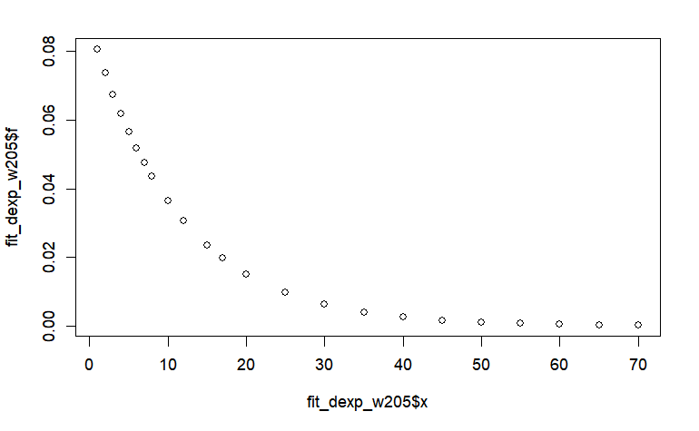

```r
fit_dexp_w205 <- data.frame(f = dexp(w_2_2005$DURATION, rate = exp_w2_2005_$estimate[1]),
                       x = w_2_2005$DURATION, type = "exp")

plot(x = fit_dexp_w205$x, y = fit_dexp_w205$f)
```

Now let’s compare these models AIC and BIC to see which fits the walk data best:

```r
#comparing these models AIC and BIC to see which fits the walk data best:
broom::glance(MASS::fitdistr(w_2_2005$DURATION%>% unlist() %>% as.numeric(),"gamma"))
```

| logLik | AIC | BIC | nobs |
| --- | --- | --- | --- |
| -3241.564 | 6487.128 | 6496.826 | 943 |

```r
broom::glance(MASS::fitdistr(w_2_2005$DURATION%>% unlist() %>% as.numeric(),"weibull"))
```

| logLik | AIC | BIC | nobs |
| --- | --- | --- | --- |
| -3254.75 | 6513.501 | 6523.199 | 943 |

```r
broom::glance(MASS::fitdistr(w_2_2005$DURATION%>% unlist() %>% as.numeric(),"exponential"))
```

| logLik | AIC | BIC | nobs |
| --- | --- | --- | --- |
| -3277.813 | 6557.625 | 6562.474 | 943 |

So, gamma has largest logLik and the smallest AIC and BIC. we will pick gamma function for walking trips in 2005!

```r
walking_205_gamma <- gamma_w2_2005_
w_2_2005 <- w_2_2005 %>%
 mutate(f_2 = dgamma(DURATION, walking_205_gamma$estimate["shape"], walking_205_gamma$estimate["rate"]))
summary(w_2_2005$f_2)
```

```
     Min.   1st Qu.    Median      Mean   3rd Qu.      Max.
5.294e-05 2.836e-02 4.469e-02 4.269e-02 6.206e-02 6.388e-02
```

###Destination : other’s home (3)

using a skew vs. kurtois graph to descriptive statistics of data

```
summary statistics
------
min:  1   max:  90
median:  5
mean:  8.660465
estimated sd:  9.687881
estimated skewness:  3.354362
estimated kurtosis:  21.69227
```

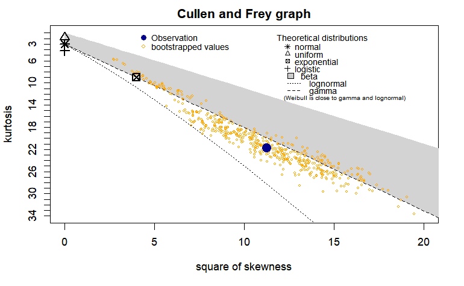

```r
# creating a skew vs. kurtois graph for walking 2005

# Filter the data based on the "destination" column
 w_3_2005 <- walking_2005 %>%
  filter(destination == "3")
descdist(w_3_2005$DURATION %>% unlist() %>% as.numeric(), discrete=FALSE, boot=500)
```

As shown in the Cullen and Frey graph, we see that gamma, weibull, lognormal and exponential will likely be the best fit according to the graph above. Then we compare these models to find the best model.

```r
# Based on the skew vs. kurtois graph the best distribution

#Calculating gamma distribution
gamma_w3_2005_ <- fitdistrplus::fitdist(data=w_3_2005$DURATION%>% unlist() %>% as.numeric(), "gamma", method="mle", optim.method="Nelder-Mead", weights = round(w_3_2005$WGHT_EPI))
fit_dgamma_w305 <- data.frame(f = dgamma(w_3_2005$DURATION, shape = gamma_w3_2005_$estimate[1], rate = gamma_w3_2005_$estimate[2]), x = w_3_2005$DURATION, type = "Gamma")

summary(gamma_w3_2005_)
```

```
Fitting of the distribution ' gamma ' by maximum likelihood
Parameters :
```

|  | estimate | Std. Error |
| --- | --- | --- |
| shape | 1.3121999 | 0.001971095 |
| rate | 0.1465656 | 0.000266865 |

```
Loglikelihood:  -2281128   AIC:  4562260   BIC:  4562269
Correlation matrix:
          shape      rate
shape 1.0000000 0.8249249
rate  0.8249249 1.0000000
```

```r
#Calculating weibull distribution
weibull_w3_2005_ <- fitdistrplus::fitdist(data=w_3_2005$DURATION%>% unlist() %>% as.numeric(), "weibull", method="mle", optim.method="Nelder-Mead", weights = round(w_3_2005$WGHT_EPI))
fit_dweibull_w305 <- data.frame(f = dweibull(w_3_2005$DURATION, shape = weibull_w3_2005_$estimate[1], scale = weibull_w3_2005_$estimate[2]), x = w_3_2005$DURATION, type = "weibull")

summary(weibull_w3_2005_)
```

```
Fitting of the distribution ' weibull ' by maximum likelihood
Parameters :
```

|  | estimate | Std. Error |
| --- | --- | --- |
| shape | 1.119816 | 0.0009779653 |
| scale | 9.370901 | 0.0104480930 |

```
Loglikelihood:  -2288396   AIC:  4576796   BIC:  4576805
Correlation matrix:
          shape     scale
shape 1.0000000 0.3287145
scale 0.3287145 1.0000000
```

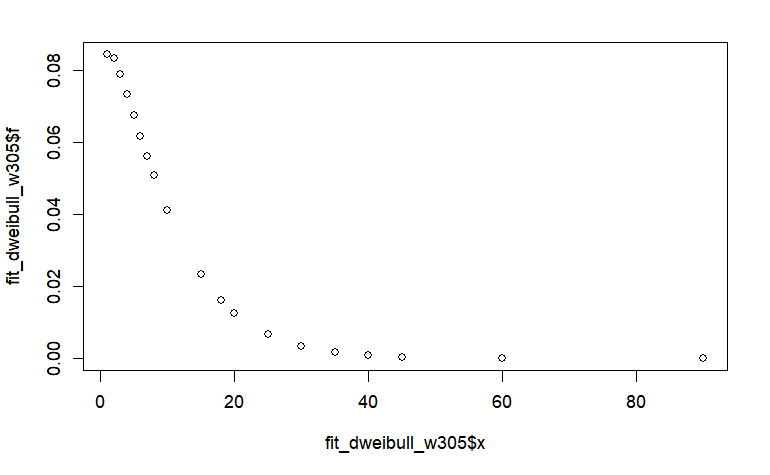

```r
plot(x= fit_dweibull_w305$x, y=fit_dweibull_w305$f)
```

```r
#Calculating lognormal distribution
lnorm_w3_2005_ <- fitdistrplus::fitdist(data=w_3_2005$DURATION%>% unlist() %>% as.numeric(), "lnorm", method="mle", optim.method="Nelder-Mead", weights = round(w_3_2005$WGHT_EPI))
fit_dlnorm_w305 <- data.frame(f = dlnorm(w_3_2005$DURATION, meanlog = lnorm_w3_2005_$estimate[1], sdlog = lnorm_w3_2005_$estimate[2]), x = w_3_2005$DURATION, type = "lnorm")

summary(lnorm_w3_2005_)
```

```
Fitting of the distribution ' lnorm ' by maximum likelihood
Parameters :
```

|  | estimate | Std. Error |
| --- | --- | --- |
| meanlog | 1.7647487 | 0.0011336684 |
| sdlog | 0.9615493 | 0.0008015561 |

```
Loglikelihood:  -2262105   AIC:  4524213   BIC:  4524222
Correlation matrix:
             meanlog        sdlog
meanlog 1.0000000000 0.0001525384
sdlog   0.0001525384 1.0000000000
```

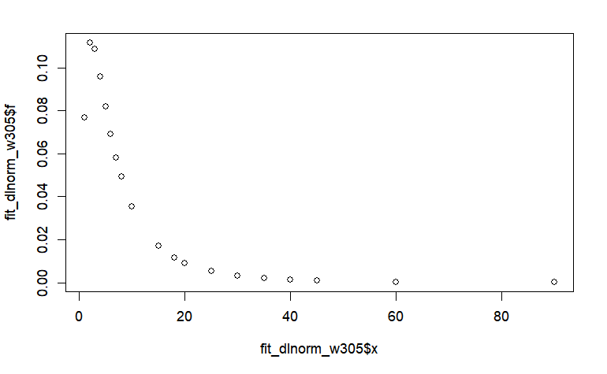

```r
plot(x= fit_dlnorm_w305$x, y=fit_dlnorm_w305$f)
```

```r
#Calculating exponential distribution
exp_w3_2005_ <- fitdistrplus::fitdist(data=w_3_2005$DURATION%>% unlist() %>% as.numeric(), "exp", method="mle", optim.method="Nelder-Mead", weights = round(w_3_2005$WGHT_EPI))
summary(exp_w3_2005_)
```

```
Fitting of the distribution ' exp ' by maximum likelihood
Parameters :
```

|  | estimate | Std. Error |
| --- | --- | --- |
| rate | 0.1116785 | 0.0001316586 |

```
Loglikelihood:  -2296294   AIC:  4592590   BIC:  4592594
```

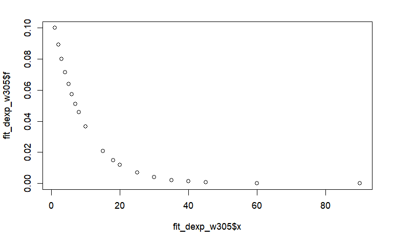

```r
fit_dexp_w305 <- data.frame(f = dexp(w_3_2005$DURATION, rate = exp_w3_2005_$estimate[1]),
                       x = w_3_2005$DURATION, type = "exp")

plot(x = fit_dexp_w305$x, y = fit_dexp_w305$f)
```

Now let’s compare these models AIC and BIC to see which fits the walk data best:

```r
#comparing these models AIC and BIC to see which fits the walk data best:
broom::glance(MASS::fitdistr(w_3_2005$DURATION%>% unlist() %>% as.numeric(),"gamma"))
```

| logLik | AIC | BIC | nobs |
| --- | --- | --- | --- |
| -2030.842 | 4065.684 | 4074.623 | 645 |

```r
broom::glance(MASS::fitdistr(w_3_2005$DURATION%>% unlist() %>% as.numeric(),"weibull"))
```

| logLik | AIC | BIC | nobs |
| --- | --- | --- | --- |
| -2035.932 | 4075.865 | 4084.803 | 645 |

```r
broom::glance(MASS::fitdistr(w_3_2005$DURATION%>% unlist() %>% as.numeric(),"lognormal"))
```

| logLik | AIC | BIC | nobs |
| --- | --- | --- | --- |
| -1996.708 | 3997.416 | 4006.355 | 645 |

```r
broom::glance(MASS::fitdistr(w_3_2005$DURATION%>% unlist() %>% as.numeric(),"exponential"))
```

| logLik | AIC | BIC | nobs |
| --- | --- | --- | --- |
| -2037.406 | 4076.811 | 4081.281 | 645 |

So, lognormal has largest logLik and the smallest AIC and BIC. we will pick lognormal function for walking trips in 2005!

```r
walking_305_lnorm <- lnorm_w3_2005_
w_3_2005 <- w_3_2005 %>%
 mutate(f_3 = dlnorm(DURATION, walking_305_lnorm$estimate["meanlog"], walking_305_lnorm$estimate["sdlog"]))
summary(w_3_2005$f_3)
```

```
     Min.   1st Qu.    Median      Mean   3rd Qu.      Max.
8.069e-05 3.548e-02 8.190e-02 6.380e-02 8.190e-02 1.115e-01
```

###Destination : Restaurant/bar (4)

using a skew vs. kurtois graph to descriptive statistics of data

```
summary statistics
------
min:  1   max:  85
median:  5
mean:  10.00774
estimated sd:  9.1338
estimated skewness:  2.869634
estimated kurtosis:  16.86707
```

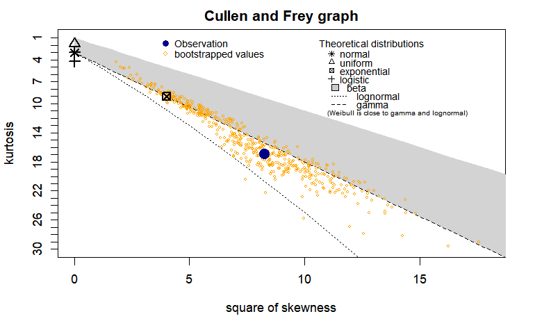

```r
# creating a skew vs. kurtois graph for walking 2005

# Filter the data based on the "destination" column
 w_4_2005 <- walking_2005 %>%
  filter(destination == "4")
descdist(w_4_2005$DURATION %>% unlist() %>% as.numeric(), discrete=FALSE, boot=500)
```

As shown in the Cullen and Frey graph, we see that gamma,weibull, lognormal and exponential will likely be the best fit according to the graph above. Then we compare these models to find the best model.

```r
# Based on the skew vs. kurtois graph the best distribution

#Calculating gamma distribution
gamma_w4_2005_ <- fitdistrplus::fitdist(data=w_4_2005$DURATION%>% unlist() %>% as.numeric(), "gamma", method="mle", optim.method="Nelder-Mead", weights = round(w_4_2005$WGHT_EPI))
fit_dgamma_w405 <- data.frame(f = dgamma(w_4_2005$DURATION, shape = gamma_w4_2005_$estimate[1], rate = gamma_w4_2005_$estimate[2]), x = w_4_2005$DURATION, type = "Gamma")

summary(gamma_w4_2005_)
```

```
Fitting of the distribution ' gamma ' by maximum likelihood
Parameters :
```

|  | estimate | Std. Error |
| --- | --- | --- |
| shape | 1.6017795 | 0.002480864 |
| rate | 0.1702337 | 0.000308936 |

```
Loglikelihood:  -2220506   AIC:  4441016   BIC:  4441025
Correlation matrix:
         shape     rate
shape 1.000000 0.853399
rate  0.853399 1.000000
```

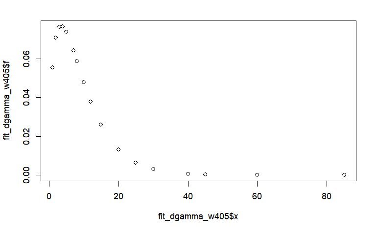

```r
plot(x= fit_dgamma_w405$x, y=fit_dgamma_w405$f)
```

```r
#Calculating weibull distribution
weibull_w4_2005_ <- fitdistrplus::fitdist(data=w_4_2005$DURATION%>% unlist() %>% as.numeric(), "weibull", method="mle", optim.method="Nelder-Mead", weights = round(w_4_2005$WGHT_EPI))
summary(weibull_w4_2005_)
```

```
Fitting of the distribution ' weibull ' by maximum likelihood
Parameters :
```

|  | estimate | Std. Error |
| --- | --- | --- |
| shape | 1.200468 | 0.001011142 |
| scale | 10.090596 | 0.010677977 |

```
Loglikelihood:  -2240442   AIC:  4480888   BIC:  4480897
Correlation matrix:
          shape     scale
shape 1.0000000 0.3337642
scale 0.3337642 1.0000000
```

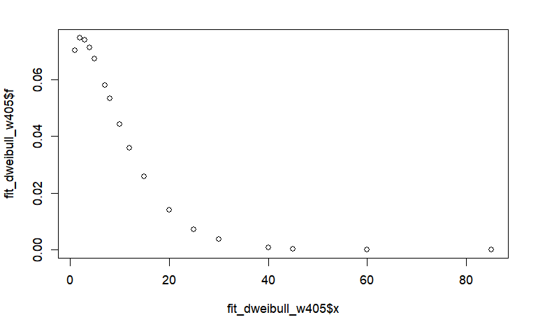

```r
fit_dweibull_w405 <- data.frame(f = dweibull(w_4_2005$DURATION, shape = weibull_w4_2005_$estimate[1], scale = weibull_w4_2005_$estimate[2]), x = w_4_2005$DURATION, type = "weibull")

plot(x= fit_dweibull_w405$x, y=fit_dweibull_w405$f)
```

```r
#Calculating exponential distribution
exp_w4_2005_ <- fitdistrplus::fitdist(data=w_4_2005$DURATION%>% unlist() %>% as.numeric(), "exp", method="mle", optim.method="Nelder-Mead", weights = round(w_4_2005$WGHT_EPI))
summary(exp_w4_2005_)
```

```
Fitting of the distribution ' exp ' by maximum likelihood
Parameters :
```

|  | estimate | Std. Error |
| --- | --- | --- |
| rate | 0.106285 | 0.0001272406 |

```
Loglikelihood:  -2261339   AIC:  4522679   BIC:  4522683
```

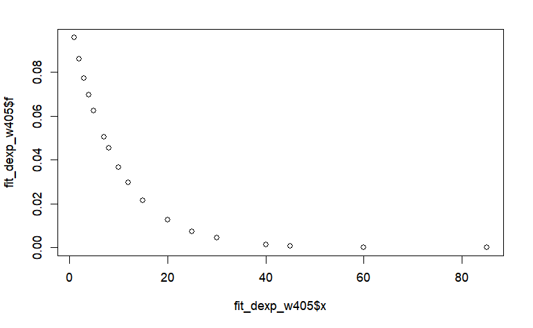

```r
fit_dexp_w405 <- data.frame(f = dexp(w_4_2005$DURATION, rate = exp_w4_2005_$estimate[1]),
                       x = w_4_2005$DURATION, type = "exp")

plot(x = fit_dexp_w405$x, y = fit_dexp_w405$f)
```

```r
#Calculating lognormal distribution
lnorm_w4_2005_ <- fitdistrplus::fitdist(data=w_4_2005$DURATION%>% unlist() %>% as.numeric(), "lnorm", method="mle", optim.method="Nelder-Mead", weights = round(w_4_2005$WGHT_EPI))
summary(lnorm_w4_2005_)
```

```
Fitting of the distribution ' lnorm ' by maximum likelihood
Parameters :
```

|  | estimate | Std. Error |
| --- | --- | --- |
| meanlog | 1.8982298 | 0.0009895471 |
| sdlog | 0.8265022 | 0.0006995897 |

```
Loglikelihood:  -2181153   AIC:  4362310   BIC:  4362318
Correlation matrix:
             meanlog        sdlog
meanlog 1.0000000000 0.0002418435
sdlog   0.0002418435 1.0000000000
```

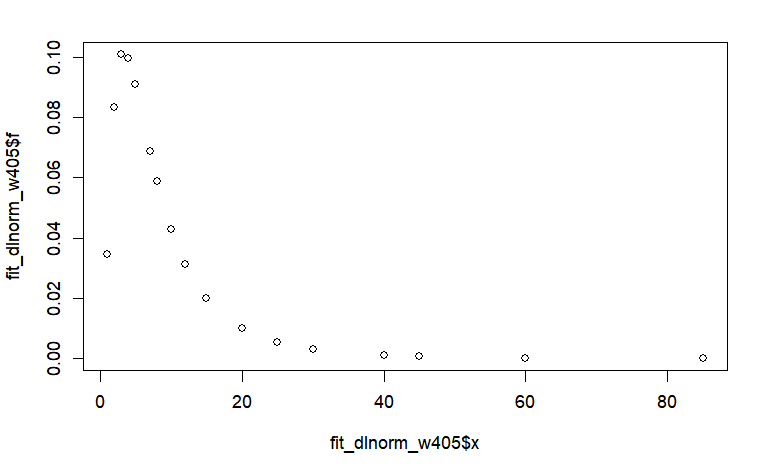

```r
fit_dlnorm_w405 <- data.frame(f = dlnorm(w_4_2005$DURATION, meanlog = lnorm_w4_2005_$estimate[1], sdlog = lnorm_w4_2005_$estimate[2]),  x = w_4_2005$DURATION, type = "lnorm")

plot(x = fit_dlnorm_w405$x, y = fit_dlnorm_w405$f)
```

Now let’s compare these models AIC and BIC to see which fits the walk data best:

```r
#comparing these models AIC and BIC to see which fits the walk data best:
broom::glance(MASS::fitdistr(w_4_2005$DURATION%>% unlist() %>% as.numeric(),"gamma"))
```

| logLik | AIC | BIC | nobs |
| --- | --- | --- | --- |
| -1672.507 | 3349.013 | 3357.509 | 517 |

```r
broom::glance(MASS::fitdistr(w_4_2005$DURATION%>% unlist() %>% as.numeric(),"weibull"))
```

| logLik | AIC | BIC | nobs |
| --- | --- | --- | --- |
| -1685.205 | 3374.411 | 3382.907 | 517 |

```r
broom::glance(MASS::fitdistr(w_4_2005$DURATION%>% unlist() %>% as.numeric(),"exponential"))
```

| logLik | AIC | BIC | nobs |
| --- | --- | --- | --- |
| -1707.836 | 3417.673 | 3421.921 | 517 |

```r
broom::glance(MASS::fitdistr(w_4_2005$DURATION%>% unlist() %>% as.numeric(),"lognormal"))
```

| logLik | AIC | BIC | nobs |
| --- | --- | --- | --- |
| -1657.239 | 3318.478 | 3326.975 | 517 |

So, lognormal has largest logLik and the smallest AIC and BIC. we will pick lognormal function for walking trips in 2005!

```r
walking_405_lnorm <- lnorm_w4_2005_
w_4_2005 <- w_4_2005 %>%
 mutate(f_4 = dlnorm(DURATION, walking_405_lnorm$estimate["meanlog"], walking_405_lnorm$estimate["sdlog"]))
summary(w_4_2005$f_4)
```

```
     Min.   1st Qu.    Median      Mean   3rd Qu.      Max.
4.969e-05 1.991e-02 4.282e-02 5.743e-02 9.082e-02 1.008e-01
```

###Destination : Place of worship (5)

using a skew vs. kurtois graph to descriptive statistics of data

```
summary statistics
------
min:  1   max:  30
median:  10
mean:  11.17021
estimated sd:  8.218006
estimated skewness:  1.150198
estimated kurtosis:  3.581987
```

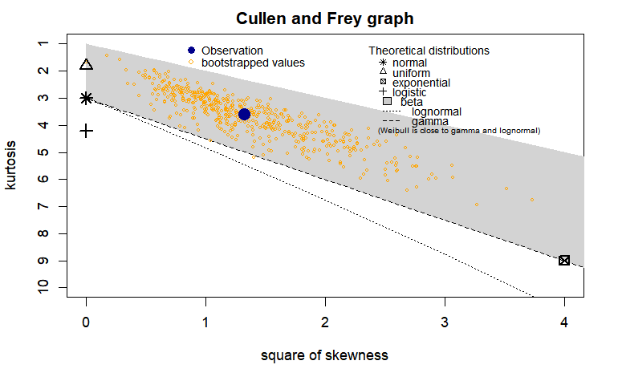

```r
# creating a skew vs. kurtois graph for walking 2005

# Filter the data based on the "destination" column
 w_5_2005 <- walking_2005 %>%
  filter(destination == "5")
descdist(w_5_2005$DURATION %>% unlist() %>% as.numeric(), discrete=FALSE, boot=500)
```

As shown in the Cullen and Frey graph, we see that gamma, and exponential will likely be the best fit according to the graph above. Then we compare these models to find the best model.

```r
# Based on the skew vs. kurtois graph the best distribution

#Calculating gamma distribution
gamma_w5_2005_ <- fitdistrplus::fitdist(data=w_5_2005$DURATION%>% unlist() %>% as.numeric(), "gamma", method="mle", optim.method="Nelder-Mead", weights = round(w_5_2005$WGHT_EPI))
fit_dgamma_w505 <- data.frame(f = dgamma(w_5_2005$DURATION, shape = gamma_w5_2005_$estimate[1], rate = gamma_w5_2005_$estimate[2]), x = w_5_2005$DURATION, type = "Gamma")

summary(gamma_w5_2005_)
```

```
Fitting of the distribution ' gamma ' by maximum likelihood
Parameters :
```

|  | estimate | Std. Error |
| --- | --- | --- |
| shape | 1.6918727 | 0.010168580 |
| rate | 0.1532441 | 0.001070262 |

```
Loglikelihood:  -155479.3   AIC:  310962.6   BIC:  310966.3
Correlation matrix:
          shape      rate
shape 1.0000000 0.8605092
rate  0.8605092 1.0000000
```

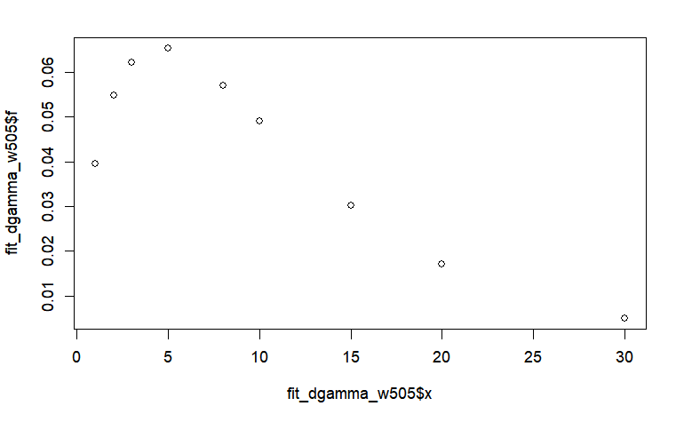

```r
plot(x= fit_dgamma_w505$x, y=fit_dgamma_w505$f)
```

```r
#Calculating exponential distribution
exp_w5_2005_ <- fitdistrplus::fitdist(data=w_5_2005$DURATION%>% unlist() %>% as.numeric(), "exp", method="mle", optim.method="Nelder-Mead", weights = round(w_5_2005$WGHT_EPI))
summary(exp_w5_2005_)
```

```
Fitting of the distribution ' exp ' by maximum likelihood
Parameters :
```

|  | estimate | Std. Error |
| --- | --- | --- |
| rate | 0.09057292 | 0.0004191242 |

```
Loglikelihood:  -158808.4   AIC:  317618.7   BIC:  317620.6
```

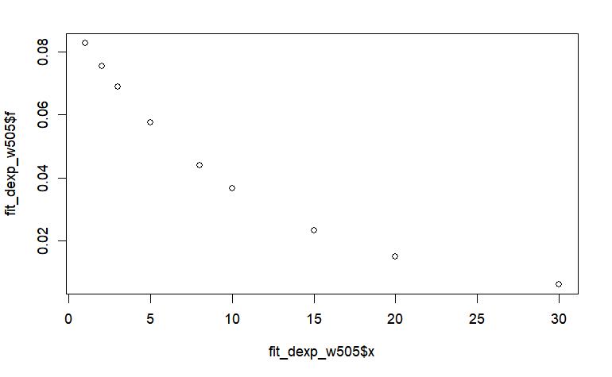

```r
fit_dexp_w505 <- data.frame(f = dexp(w_5_2005$DURATION, rate = exp_w5_2005_$estimate[1]),
                       x = w_5_2005$DURATION, type = "exp")

plot(x = fit_dexp_w505$x, y = fit_dexp_w505$f)
```

Now let’s compare these models AIC and BIC to see which fits the walk data best:

```r
#comparing these models AIC and BIC to see which fits the walk data best:
broom::glance(MASS::fitdistr(w_5_2005$DURATION%>% unlist() %>% as.numeric(),"gamma"))
```

| logLik | AIC | BIC | nobs |
| --- | --- | --- | --- |
| -154.9662 | 313.9324 | 317.6327 | 47 |

```r
broom::glance(MASS::fitdistr(w_5_2005$DURATION%>% unlist() %>% as.numeric(),"exponential"))
```

| logLik | AIC | BIC | nobs |
| --- | --- | --- | --- |
| -160.4228 | 322.8456 | 324.6957 | 47 |

So, gamma has largest logLik and the smallest AIC and BIC. we will pick gamma function for walking trips in 2005!

```r
walking_505_gamma <- gamma_w5_2005_
w_5_2005 <- w_5_2005 %>%
 mutate(f_5 = dgamma(DURATION, walking_505_gamma$estimate["shape"], walking_505_gamma$estimate["rate"]))
summary(w_5_2005$f_5)
```

```
    Min.  1st Qu.   Median     Mean  3rd Qu.     Max.
0.004892 0.030166 0.049028 0.045043 0.065304 0.065304
```

###Destination :Grocery store, other stores or mall (6 and 7)

using a skew vs. kurtois graph to descriptive statistics of data

```r
# creating a skew vs. kurtois graph for walking 2005

# Filter the data based on the "destination" column
 w_6_2005 <- walking_2005 %>%
  filter(destination %in% c("6", "7"))
descdist(w_6_2005$DURATION %>% unlist() %>% as.numeric(), discrete=FALSE, boot=500)
```

[output not shown]

```r
# Based on the skew vs. kurtois graph the best distribution

#Calculating gamma distribution
gamma_w6_2005_ <- fitdistrplus::fitdist(data=w_6_2005$DURATION%>% unlist() %>% as.numeric(), "gamma", method="mle", optim.method="Nelder-Mead", weights = round(w_6_2005$WGHT_EPI))
fit_dgamma_w605 <- data.frame(f = dgamma(w_6_2005$DURATION, shape = gamma_w6_2005_$estimate[1], rate = gamma_w6_2005_$estimate[2]), x = w_6_2005$DURATION, type = "Gamma")

summary(gamma_w6_2005_)
```

```
Fitting of the distribution ' gamma ' by maximum likelihood
Parameters :
```

|  | estimate | Std. Error |
| --- | --- | --- |
| shape | 1.4121896 | 0.002009743 |
| rate | 0.1174651 | 0.000199972 |

```
Loglikelihood:  -2799977   AIC:  5599959   BIC:  5599968
Correlation matrix:
          shape      rate
shape 1.0000000 0.8358624
rate  0.8358624 1.0000000
```

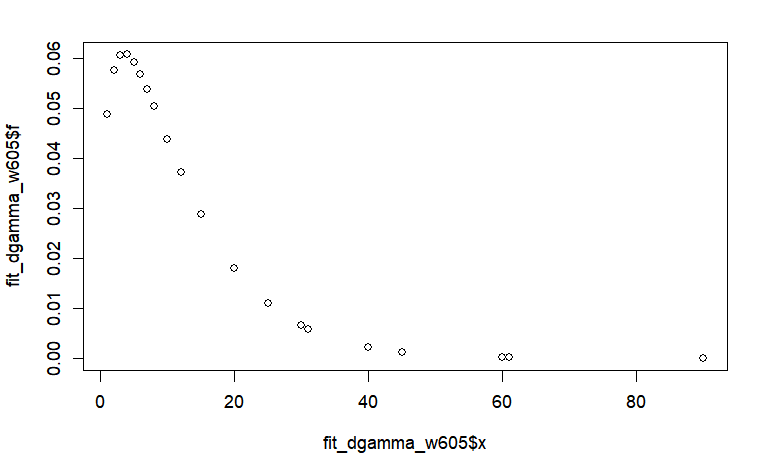

```r
plot(x= fit_dgamma_w605$x, y=fit_dgamma_w605$f)
```

```r
#Calculating weibull distribution
weibull_w6_2005_ <- fitdistrplus::fitdist(data=w_6_2005$DURATION%>% unlist() %>% as.numeric(), "weibull", method="mle", optim.method="Nelder-Mead", weights = round(w_6_2005$WGHT_EPI))
summary(weibull_w6_2005_)
```

```
Fitting of the distribution ' weibull ' by maximum likelihood
Parameters :
```

|  | estimate | Std. Error |
| --- | --- | --- |
| shape | 1.171939 | 0.0009645287 |
| scale | 12.759943 | 0.0127983774 |

```
Loglikelihood:  -2809743   AIC:  5619490   BIC:  5619499
Correlation matrix:
          shape     scale
shape 1.0000000 0.3276465
scale 0.3276465 1.0000000
```

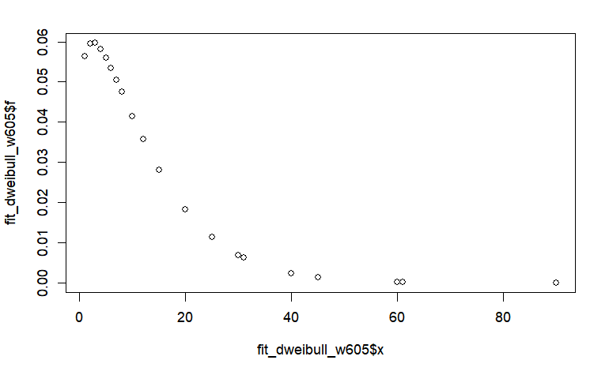

```r
fit_dweibull_w605 <- data.frame(f = dweibull(w_6_2005$DURATION, shape = weibull_w6_2005_$estimate[1], scale = weibull_w6_2005_$estimate[2]), x = w_6_2005$DURATION, type = "weibull")

plot(x= fit_dweibull_w605$x, y=fit_dweibull_w605$f)
```

```r
#Calculating exponential distribution
exp_w6_2005_ <- fitdistrplus::fitdist(data=w_6_2005$DURATION%>% unlist() %>% as.numeric(), "exp", method="mle", optim.method="Nelder-Mead", weights = round(w_6_2005$WGHT_EPI))
summary(exp_w6_2005_)
```

```
Fitting of the distribution ' exp ' by maximum likelihood
Parameters :
```

|  | estimate | Std. Error |
| --- | --- | --- |
| rate | 0.0831549 | 9.233949e-05 |

```
Loglikelihood:  -2826753   AIC:  5653509   BIC:  5653513
```

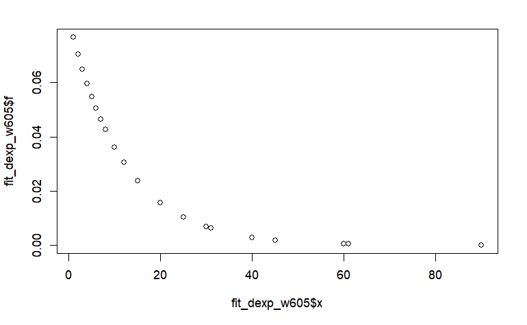

```r
fit_dexp_w605 <- data.frame(f = dexp(w_6_2005$DURATION, rate = exp_w6_2005_$estimate[1]),
                       x = w_6_2005$DURATION, type = "exp")

plot(x = fit_dexp_w605$x, y = fit_dexp_w605$f)
```

Now let’s compare these models AIC and BIC to see which fits the walk data best:

```r
#comparing these models AIC and BIC to see which fits the walk data best:
broom::glance(MASS::fitdistr(w_6_2005$DURATION%>% unlist() %>% as.numeric(),"gamma"))
```

| logLik | AIC | BIC | nobs |
| --- | --- | --- | --- |
| -2374.415 | 4752.829 | 4761.906 | 691 |

```r
broom::glance(MASS::fitdistr(w_6_2005$DURATION%>% unlist() %>% as.numeric(),"weibull"))
```

| logLik | AIC | BIC | nobs |
| --- | --- | --- | --- |
| -2383.108 | 4770.215 | 4779.291 | 691 |

```r
broom::glance(MASS::fitdistr(w_6_2005$DURATION%>% unlist() %>% as.numeric(),"exponential"))
```

| logLik | AIC | BIC | nobs |
| --- | --- | --- | --- |
| -2395.371 | 4792.742 | 4797.28 | 691 |

So, gamma has largest logLik and the smallest AIC and BIC. we will pick gamma function for walking trips in 2005!

```r
walking_605_gamma <- gamma_w6_2005_
w_6_2005 <- w_6_2005 %>%
 mutate(f_6 = dgamma(DURATION, walking_605_gamma$estimate["shape"], walking_605_gamma$estimate["rate"]))
summary(w_6_2005$f_6)
```

```
     Min.   1st Qu.    Median      Mean   3rd Qu.      Max.
8.970e-06 2.873e-02 4.373e-02 4.150e-02 5.913e-02 6.066e-02
```

###Destination : Outdoors (9)

using a skew vs. kurtois graph to descriptive statistics of data

```
summary statistics
------
min:  1   max:  60
median:  5
mean:  9.434343
estimated sd:  8.995951
estimated skewness:  2.347388
estimated kurtosis:  10.38165
```

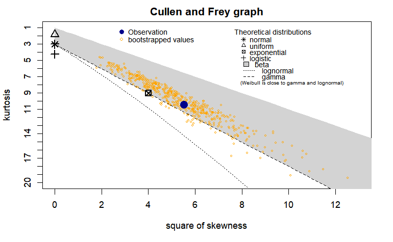

```r
# creating a skew vs. kurtois graph for walking 2005

# Filter the data based on the "destination" column
 w_9_2005 <- walking_2005 %>%
  filter(destination == "9")
descdist(w_9_2005$DURATION %>% unlist() %>% as.numeric(), discrete=FALSE, boot=500)
```

```r
# Based on the skew vs. kurtois graph the best distribution

#Calculating gamma distribution
gamma_w9_2005_ <- fitdistrplus::fitdist(data=w_9_2005$DURATION%>% unlist() %>% as.numeric(), "gamma", method="mle", optim.method="Nelder-Mead", weights = round(w_9_2005$WGHT_EPI))
fit_dgamma_w905 <- data.frame(f = dgamma(w_9_2005$DURATION, shape = gamma_w9_2005_$estimate[1], rate = gamma_w9_2005_$estimate[2]), x = w_9_2005$DURATION, type = "Gamma")

summary(gamma_w9_2005_)
```

```
Fitting of the distribution ' gamma ' by maximum likelihood
Parameters :
```

|  | estimate | Std. Error |
| --- | --- | --- |
| shape | 1.535528 | 0.0040508012 |
| rate | 0.156302 | 0.0004863804 |

```
Loglikelihood:  -773174.5   AIC:  1546353   BIC:  1546360
Correlation matrix:
       shape   rate
shape 1.0000 0.8477
rate  0.8477 1.0000
```

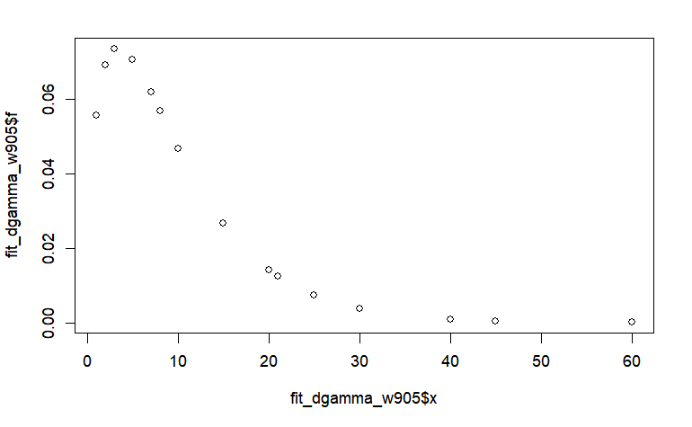

```r
plot(x= fit_dgamma_w905$x, y=fit_dgamma_w905$f)
```

```r
#Calculating exponential distribution
exp_w9_2005_ <- fitdistrplus::fitdist(data=w_9_2005$DURATION%>% unlist() %>% as.numeric(), "exp", method="mle", optim.method="Nelder-Mead", weights = round(w_9_2005$WGHT_EPI))
summary(exp_w9_2005_)
```

```
Fitting of the distribution ' exp ' by maximum likelihood
Parameters :
```

|  | estimate | Std. Error |
| --- | --- | --- |
| rate | 0.1018139 | 0.0002082518 |

```
Loglikelihood:  -784957.6   AIC:  1569917   BIC:  1569921
```

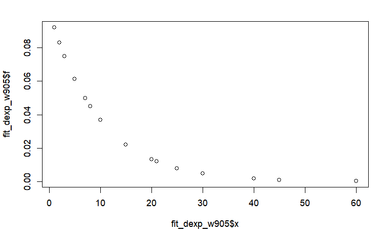

```r
fit_dexp_w905 <- data.frame(f = dexp(w_9_2005$DURATION, rate = exp_w9_2005_$estimate[1]),
                       x = w_9_2005$DURATION, type = "exp")

plot(x = fit_dexp_w905$x, y = fit_dexp_w905$f)
```

```r
#Calculating normal distribution
norm_w9_2005_ <- fitdistrplus::fitdist(data=w_9_2005$DURATION%>% unlist() %>% as.numeric(), "norm", method="mle", optim.method="Nelder-Mead", weights = round(w_9_2005$WGHT_EPI))
summary(norm_w9_2005_)
```

```
Fitting of the distribution ' norm ' by maximum likelihood
Parameters :
```

|  | estimate | Std. Error |
| --- | --- | --- |
| mean | 9.823283 | 0.01867493 |
| sd | 9.129252 | 0.01320426 |

```
Loglikelihood:  -867591.2   AIC:  1735186   BIC:  1735193
Correlation matrix:
             mean           sd
mean 1.0000000000 0.0001069898
sd   0.0001069898 1.0000000000
```

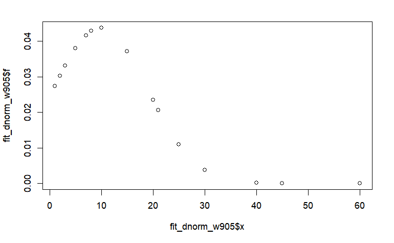

```r
fit_dnorm_w905 <- data.frame(f = dnorm(w_9_2005$DURATION, mean = norm_w9_2005_$estimate[1], sd = norm_w9_2005_$estimate[2]),  x = w_9_2005$DURATION, type = "norm")

plot(x = fit_dnorm_w905$x, y = fit_dnorm_w905$f)
```

Now let’s compare these models AIC and BIC to see which fits the walk data best:

```r
#comparing these models AIC and BIC to see which fits the walk data best:
broom::glance(MASS::fitdistr(w_9_2005$DURATION%>% unlist() %>% as.numeric(),"gamma"))
```

| logLik | AIC | BIC | nobs |
| --- | --- | --- | --- |
| -634.3659 | 1272.732 | 1279.308 | 198 |

```r
broom::glance(MASS::fitdistr(w_9_2005$DURATION%>% unlist() %>% as.numeric(),"exponential"))
```

| logLik | AIC | BIC | nobs |
| --- | --- | --- | --- |
| -642.3826 | 1286.765 | 1290.053 | 198 |

```r
broom::glance(MASS::fitdistr(w_9_2005$DURATION%>% unlist() %>% as.numeric(),"normal"))
```

| logLik | AIC | BIC | nobs |
| --- | --- | --- | --- |
| -715.4099 | 1434.82 | 1441.396 | 198 |

So, gamma has largest logLik and the smallest AIC and BIC. we will pick gamma function for walking trips in 2005!

```r
walking_905_gamma <- gamma_w9_2005_
w_9_2005 <- w_9_2005 %>%
 mutate(f_9 = dgamma(DURATION, walking_905_gamma$estimate["shape"], walking_905_gamma$estimate["rate"]))
summary(w_9_2005$f_9)
```

```
     Min.   1st Qu.    Median      Mean   3rd Qu.      Max.
4.936e-05 4.685e-02 5.934e-02 5.197e-02 7.061e-02 7.342e-02
```

###Destination : Outdoors (10)